# 패션 플랫폼 리뷰 토픽 모델링을 통한 의류 브랜드 마케팅 전략 제고

## 무신사 입점 브랜드 리뷰를 중심으로

비즈니스 인포메틱스 2022139817 함동호

## 서론

- 과거 의류 같은 경우 소비자마다 다른 체형으로 인해 직접 눈으로 만져보고 입어봐야 하는 과정이 있어 온라인 플랫폼 시장이 성장하기 힘들었다.
- 하지만 코로나 19와 이커머스 시장의 발달에 힘입어 온라인 패션 플랫폼 시장도 빠르게 변화하며 소비자들을 흡수하고 있다.
- 소비자들의 리뷰를 통해 가감없는 제품 평가로 소비자의 신뢰감을 얻기 위해 노력하고 있다.
- 소비자들이 남긴 리뷰를 분석한다면 여러 패션 브랜드들은 브랜드에 대한 소비자들의 의견을 파악할 수 있을 뿐만 아니라 향후 마케팅 전략을 수립하는 요소로 활용할 수 있을 것이다.

## 본론

1. 문헌 연구

```
1.1 토픽 모델링
텍스트 마이닝이란 텍스트를 언어학, 수학, 통계학, 컴퓨터공학 등의 학문적 지식을 이용하여 특정 목적에 맞게 유의미한 정보를 추출하는 분석 및 처리 과정을 텍스트 마이닝이라고 한다. 그 중 토픽 모델링은 텍스트 마이닝에서 사용하는 방법론이다. 토픽 모델링이란 기계 학습 및 자연어 처리 분야에서 토픽이라는 문서 집합의 추상적인 주제를 발견하기 위한 통계적 모델 중 하나로, 텍스트 본문의 숨겨진 의미 구조를 발견하기 위해 사용되는 비지도 학습 알고리즘 중 하나이다. 토픽 모델링 중 가장 대표적으로 사용되는 LDA(Latent Dirichlet Allocation)는 단어나 문서의 숨겨진 주제를 찾아준다. 여기서 주제(Topic)란, 수집된 원문 내용에 담긴 다양한 키워드를 기반으로 내용을 유형화(그룹화) 시켜주는 것이다. LDA 기법은 단순히 주제만 분류하는 것이 아니라 주제에 포함되는 키워드들을 보여주기 때문에 키워드들을 통해 주제를 해석하고 정의할 수 있다.

1.2 온라인 리뷰 분석
강범일 외(2013)의 연구에서는 토픽 모델링 기법을 이용해 신문 기사의 주제를 파악하는 연구를 진행했다. 김광국 외(2018) 연구에서는 모바일 쇼핑 앱 사용자들의 다양하고 구체적인 요구사항을 추출하기 위하여 앱 마켓에 있는 사용자 리뷰에 대한 토픽 분석을 수행했다. 정상빈 외(2020) 연구에서는 모바일 커머스를 대상으로 고객이 작성한 리뷰의 계량적, 비계량적 특성이 판매 성과와 어떠한 영향을 미치는지에 대하여 분석했다.
```

<표 1 토픽모델링 및 리뷰 분석 관련 선행 연구>

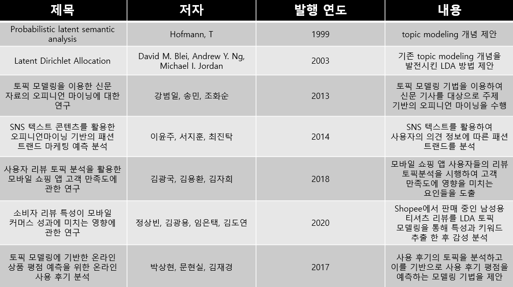

1. 연구 모형

<그림 1 연구 모형>

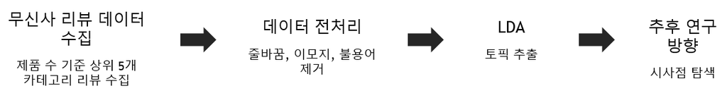

먼저 연구 순서는 데이터 수집, 전처리, LDA 토픽 분석 순으로 진행된다. 데이터 수집은 무신사에서 12월 1일 기준 인기 카테고리에서 수집했다. 인기 카테고리 중 상품 수 기준 상위 5개 제품 군에서 리뷰 데이터를 수집했다. 수집한 제품 군은 니트, 맨투맨/스웻, 모자, 바지, 후드이다. 제품 군에서 모든 제품을 수집하기에는 시간 상 불가능해 무신사 추천 순으로 상위 10개 상품의 리뷰를 수집했다.

<그림 2 스타일 리뷰 예시>

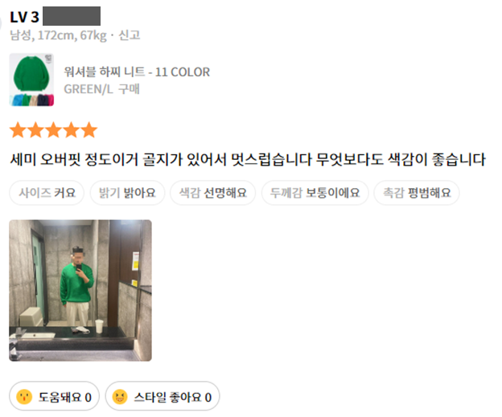

데이터 수집 후 모델링에서 좋은 결과를 얻기 위해 다음과 같은 전처리 과정을 거쳤다. 먼저 무의미하거나 불필요한 단어들을 삭제했다. ‘!, ?, ;, .’과 같은 단어들은 빈번하게 등장할 가능성이 높고 의미를 담고 있는 단어들이 아니라 삭제할 필요가 있다. 또한 관사, 전치사, 접속사, 조사와 같은 불용어(stopwords)들을 삭제했다. 온라인 리뷰의 경우 문어체와 달리 다양한 불용어가 존재하고, 비속어, 오타 등이 많아 직접 불용어 사전을 구축해 불용어를 제거했다. 모바일에서 작성된 리뷰의 경우 다양한 이모티콘이 포함되어 있어 이모티콘을 제거했다. 특수문자, 불용어, 이모티콘 등을 제거하고 원활한 토큰화를 위해 PyKoSpacing을 사용해 띄어쓰기한 문장으로 변환했다. PyKoSpacing은 오픈소스 라이브러리로 만들어진 한국어 띄어쓰기 패키지로 띄어쓰기가 되어 있지 않은 문장을 띄어쓰기 한 문장으로 변환해주는 패키지이다. PyKoSpacing은 대용량 코퍼스를 학습하여 만들어진 띄어쓰기 딥러닝 모델로 준수한 성능을 가지고 있다.

본 연구에서는 한국어 토큰화를 위해 KoNLPy 라이브러리를 사용한다. KoNLPy를 통해서 사용할 수 있는 형태소 분석기로는 Okt(Open Korea Text), 메캅(Mecab), 코모란(Komoran), 한나눔(Hannanum), 꼬꼬마(kkma)가 있다. 한국어 자연어처리(NLP)에서 사용하는 형태소 분석기는 단어 토큰화가 아니라 정확히는 형태소(morpheme) 단위로 형태소 토큰화(morpheme tokenization)를 수행할 수 있다(백성열, 2022). 본 연구에서는 가장 처리 속도가 빠르다고 알려진 mecab을 통해서 한국어 단어 토큰화를 진행했다.

단어 토큰화 이후 LDA를 통해 주요 단어들을 확인했다. 잠재 디리클레 할당(Latent Dirichelt Allocation, LDA)는 토픽 모델링의 대표적인 알고리즘이다. 구체적으로, LDA 토픽 모델링은 확률 기반의 모델링 기법을 통해 방대한 양의 문서 데이터를 분석함으로써 문서 내에 어떤 토픽이, 어떤 비율로 구성되어 있는지 분석한다. 또한 토픽 별로 어떤 키워드가 구성되었는지 정보를 제공하기 때문에, 키워드 조합을 통해 인사이트를 도출하는데 효과적이다.

<그림 3> LDA 구조

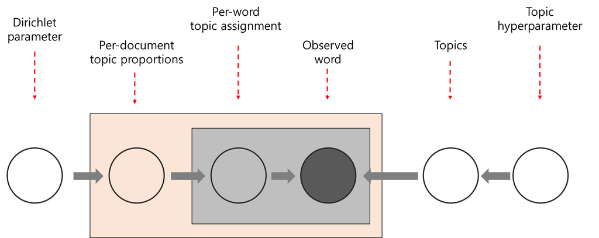

1. 데이터 설명

<표 2> 데이터 수집 종류

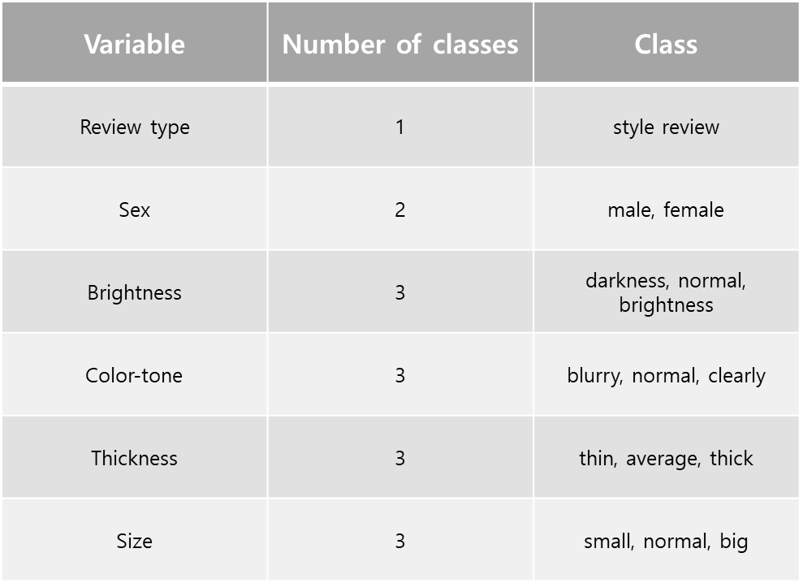

본 연구에서 사용한 데이터는 인기 카테고리에 있는 니트, 맨투맨/스웻, 모자, 바지, 후드 카테고리에서 리뷰 텍스트이다. 각각 카테고리 별로 무신사 추천 순 상위 10개의 제품의 리뷰를 일부분 수집했다. 수집 기간은 12월 1일 기준으로 총 5개 카테고리에 대해 24,400개의 리뷰 데이터를 수집했다. 선행연구들에서 사용한 리뷰 종류는 스타일, 제품, 일반 리뷰들이지만 본 연구에서는 양질의 리뷰를 수집하기 위해 스타일 리뷰만 수집했다. 또한 리뷰 데이터와 리뷰어의 여러 메타데이터를 추가적으로 수집했다.

<표 3> 데이터 수집 결과

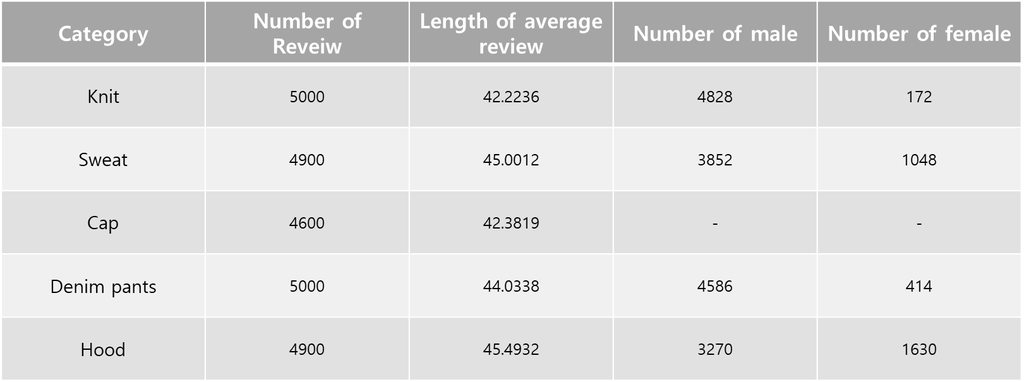

다음은 데이터 수집 결과이다. 총 5개 카테고리의 24,400개의 리뷰가 수집되었다. 카테고리 별로 무신사 추천 순 상위 10개 제품의 리뷰를 5000개에 가깝도록 수집했지만 리뷰 개수가 부족한 경우도 있어 수집된 리뷰의 개수는 모두 다르다.

<표 4> 단어별 등장 빈도

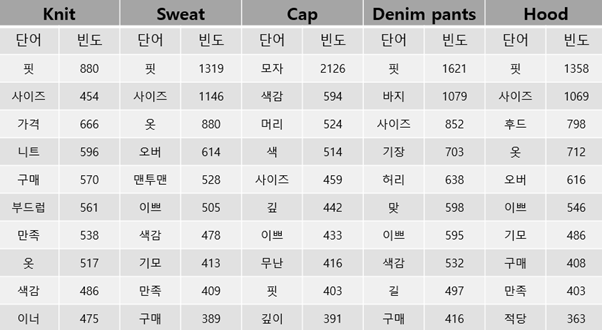

1. 분석 결과

니트 카테고리의 LDA 분석 결과는 다음과 같다.

<표 5> 니트 토픽 모델링

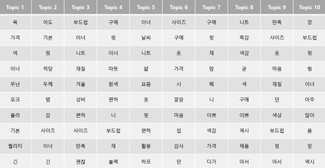

주로 추출된 토픽은 목, 가격, 사이즈, 만족 등이 있었다. 토픽 모델링을 통해 니트 카테고리의 제품들을 구매한 소비자들의 여론을 알 수 있었다. 피부에 직접적으로 닿는 제품이다 보니 ‘목’, ‘재질’, ‘이너’, ‘부드럽’ 등의 단어가 추출됨을 확인할 수 있다. 니트 종류는 주로 겨울에 입는 특성 상 ‘따뜻’, ‘두께’, ‘얇’, ‘편하’와 같이 보온을 중요시 하는 소비자들의 실용성과 관련된 단어도 확인할 수 있다. 여러 토픽에서 공통적으로 확인할 수 있는 단어는 ‘사이즈’, ‘핏’, ‘색감’으로 오프라인 매장과 달리 소비자들이 옷을 입어보고 구매할 수 없기 때문에 구매자 체형에 어울림을 설명하는 해당 단어가 빈번하게 등장한 것으로 추측할 수 있다.

특이한 점은 Topic 10에서 ‘깡’이라는 단어가 등장했는데, 해당 리뷰를 찾아보니 남성 패션 전문 유튜버가 출시한 제품으로 출시 후 많은 사람들의 관심을 받아 리뷰가 많이 남겨져 있음을 확인할 수 있다.

<표 6> 맨투맨/스웨트 토픽 모델링

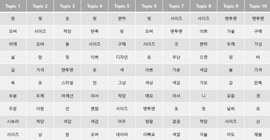

다음은 맨투맨/스웻 토픽 모델링 결과이다. 니트와 마찬가지로 오프라인 매장의 특성을 반영하는 ‘핏’, ‘사이즈’, ‘색감’과 같은 구매자의 체형 혹은 선호와 관련된 단어들이 등장함을 알 수 있다.

니트와 다른 점으로는 ‘오버’라는 단어가 포함 되었다는 점이다. 최근 오버핏의 유행으로 해당 단어가 포함 되었음을 추측할 수 있다. 본인의 체형에 맞게 입고, 격식을 갖춰야 하는 자리에 주로 입는 니트와 달리 맨투맨 혹은 스웻은 캐주얼한 상황에서 사람들이 즐겨 입기 때문에 활동하기 편한 오버핏을 선호한다. 오버핏과 관련된 ‘어깨선’과 ‘어깨’도 토픽으로 선정되었음을 확인할 수 있다. 또한 특정 색이 토픽으로 선정되었다. ‘네이비’라는 구체적인 색을 표현하는 단어가 등장했는데 이를 통해 소비자들이 선호하는 색이 무엇인지 확인할 수 있었다.

보온과 실용성을 위해 ‘두께’가 토픽으로 선정된 니트와 달리 맨투맨에서는 ‘두께’와 추가로 ‘기모’가 토픽으로 선정되었다. 옷의 재질 상 옷에 ‘기모’를 덧댈 수 있고, 낮은 온도에서 맨투맨과 스웻을 주로 입기 때문에 보온성과 실용성을 소비자들이 제품 구매에 판단 기준으로 삼았음을 알 수 있다. 비슷한 이유로 ‘날씨’, ‘가을’, ‘겨울’ 토픽도 선정 되었음을 확인할 수 있다.

맨투맨과 스웻은 편한 분위기에서 주로 입기 때문에 무신사 플랫폼 이용자들이 비싼 가격의 제품 보다는 적당한 가격대의 제품을 선호함을 알 수 있다. 이에 대한 근거로 ‘가성비’와 ‘가격’이 토픽으로 선정 되었음을 알 수 있다.

<표 7>모자토픽모델링

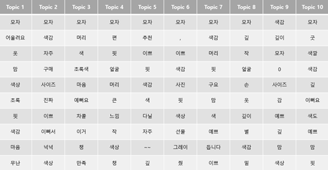

여러 카테고리 중 유일하게 ‘깊’, ‘깊이’, ‘머리’와 같은 단어가 등장함을 확인할 수 있다. 이는 모자를 구매하는 소비자들이 체형을 가리거나 숨기려고 할 때 모자를 사용함을 추측할 수 있다. 해당 토픽 모델링을 통해서 소비자들이 모자를 사용하는 용도에 대해 확인해볼 수 있었다.

<표 8> 데님팬츠 토픽 모델링

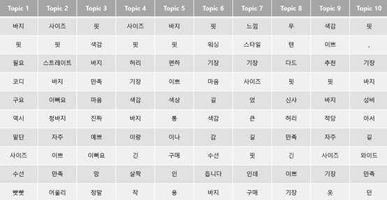

다른 카테고리의 제품에서 동일하게 볼 수 있는 ‘사이즈’, ‘핏’, ‘색감’이 동일하게 등장했다. 니트, 맨투맨/스웻과 달리 바지는 ‘사이즈’ 단어와 같이 ‘허리’와 ‘밑단’ 단어가 토픽으로 선정 되었다. 바지의 경우 상의에 비해 허리, 허벅지, 엉덩이 사이즈가 소비자 별로 더 다양할 수 있기 때문에 해당 단어들이 자주 등장한 것으로 추측할 수 있다. 또한 상의 제품 군들과 달리 바지는 사이즈가 달라도 소비자의 체형에 맞게 수선이 상대적으로 용이하기 때문에 ‘수선’ 단어가 토픽으로 선정 되었음을 추측할 수 있다.

Topic 8에서는 ‘무’, ‘탠’, ‘다드’가 상위 토픽으로 선정 되었는데 그 이유는 다음과 같다. 무텐다드는 무신사의 자체 PB 브랜드로 런칭한 이후 소비자들에게 꾸준히 사랑 받고 있다. 무탠다드는 상의와 하의 제품 뿐만 아니라 여러 악세서리 제품들도 출시하고 있는데 하의 제품 군에서 인기가 많은 것을 토픽 모델링을 통해 확인할 수 있다

<표 9> 푸드 티셔츠 토픽 모델링

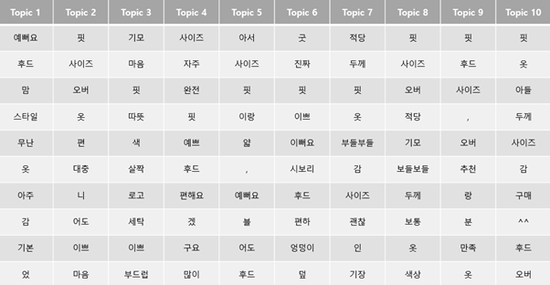

다른 상의 카테고리 제품 리뷰와 동일하게 ‘사이즈’, ‘핏’, ‘오버’가 동일하게 등장했다. 후드 티셔츠도 맨투맨/스웻과 동일하게 오버핏을 소비자들이 선호하고, 겨울에 입는 제품이니 ‘기모’, ‘두께’ 단어도 토픽으로 선정되었다.

반면에 후드 티셔츠에서만 등장한 토픽도 있다. ‘세탁’이 후드 티셔츠에만 등장했는데 다른 제품들과 달리 옷에 모자가 달려 있어 소비자들이 세탁할 때 더욱 신경 씀을 추측해볼 수 있다. 또한 니트에서 ‘촉감’ 토픽이 등장한 것과 별개로 구체적인 옷의 느낌을 언급하는 ‘부들부들’, ‘보들보들’과 같은 토픽들이 등장했는데 후드 티셔츠도 피부에 닿는 제품이니만큼 소비자들이 촉감을 구매 기준 중 하나로 선택했음을 추측해볼 수 있다.

## 결론

본 연구에서는 최근 가파른 성장세로 성장하고 있는 모바일 패션 플랫폼인 무신사의 제품 리뷰를 LDA 방법을 통해 토픽 모델링하여 다양한 소비자들의 의견을 파악해보았다.

본 연구의 차별점은 제품 카테고리 별로 토픽 모델링을 진행하였다는 것이다. 무신사에 존재하는 제품의 리뷰를 카테고리 별로 토픽 모델링을 해 각 카테고리 별 소비자 리뷰에서 어떤 단어가 주요하게 언급 되었는지 확인할 수 있다. 또한 이를 통해 카테고리 별로 공통적으로 언급된 단어와 다르게 언급된 단어는 어떤 단어인지 확인해 카테고리 별로 소비자의 여론을 파악하였다.

추후 연구 방향은 다음과 같다. 첫째, 데이터 추가 수집. 본 연구에서는 시간 제약으로 5개 카테고리의 일부 리뷰만 수집하였다. 현재 무신사에는 100개가 넘는 카테고리가 있어 더욱 더 다양한 리뷰를 수집할 수 있을 것으로 기대한다. 본 연구에서는 남성 소비자만 분석하는 것을 목표로 삼았지만 연구 기간 안에 충분한 리뷰를 수집하지 못해 모든 성별의 리뷰를 분석했다. 추후 더 많은 리뷰를 수집한다면 남성 소비자들의 리뷰만 분석할 수 있을 것으로 예상한다. 둘째, 클러스터링 및 tf-idf 분석. LDA을 활용한 토픽 모델링 뿐만 아니라 수집한 리뷰들을 문서 군집화를 한 후 tf-idf 분석을 통해 어떤 단어가 비중 있는지 확인할 수 있다면 더 정확한 리뷰 분석이 가능할 것이다.